# Homework 4

- Show All Code
- Hide All Code
- View Source

Author

Affiliation

David Sneddon

Old Dominion University

Primary, secondary, and post-secondary education all lead to increased human capital, an important factor in driving long run economic growth, worker productivity, employment, innovation, and other important economic outcomes. The production of education takes many forms. For example, primary and secondary education markets contain public schools, schools operated by various religious faiths (the Catholic church, various fundamentalist religions, etc.), as well as private non-denominational organizations like charter schools. Because of the economic importance of education and human capital formation, research on the effectiveness of different forms of education is interesting and important.

Private Catholic schools represent a common alternative to public schools in many communities. A large body of economic research focuses on how different types of education, in particular Catholic versus public school education, affects educational outcomes. This research primarily focuses on grades, but some papers examine high school graduation rates and rates of college attendance.

This research faces a number of important econometric challenges. One key challenge stems from the fact that the decision to enroll a child in Catholic or public schools reflects parental choice and **not** random assignment. School enrollment decisions reflect many factors at the family and individual level. While public school attendance is free of charge, and financed by taxes, private education like attendance at a Catholic school requires paying tuition, making family income an important factor. Income may also affect educational outcomes independent of school choice, for example through tutoring, educational software, and other unobservable factors, making income a likely back door.

In a “dream” world, a team of economists could obtain a sample of 10,000 students and randomly assign them to either a Catholic school or a public school. In this situation, we could have more confidence in estimates of a casual treatment effect of school type on educational outcomes. However, for obvious reasons, this is not possible. Instead, education economists frequently use matching methods like Propensity Score Matching to come up with as-if random assignment of catholic school education to generate more plausible causal estimates. This homework applies matching methods to a data set containing information on school enrollment, grades, and family characteristics.

## Question 1

Explore whether catholic school education improves outcomes. The data for this homework can be found [here](https://alexcardazzi.github.io/econ400/data/catholic2.csv) ([codebook](https://alexcardazzi.github.io/econ400/data/ecls-codebook.txt)).

1. Read in the data and store it as an object called `school`. (**1 Point**)

```r
school <- read.csv("https://alexcardazzi.github.io/econ400/data/catholic2.csv")
```

2. Change the column names to the following: (**2 Points**)
- `c5r2mtsc` : `math_score`
- `c5r2mtsc_std` : `math_std`
- `p5hmage` : `mom_age`
- `w3momed_hsb` : `mom_noCollege`
- `w3income` : `income`
- `catholic` : `catholic` (no change, this is just for completeness)
- `income2` : `income2` (no change, this is just for completeness)

```r
colnames(school) <- c("math_score", "math_std", "mom_age", "mom_noCollege", "income", "catholic", "income2")
```

3. Calculate the percent of students who attended catholic school. (**1 Point**)

```r
paste0(round(mean(school$catholic)*100,2),"%")
```

**Output**

```
[1] "15.79%"
```

4. Use `modelsummary` to create a summary statistics table for students who did not attend catholic school. (**1 Point**)

```r
library("modelsummary")
options(modelsummary_factory_default = 'kableExtra')
options("modelsummary_format_numeric_latex" = "plain")
secular <- school[school$catholic==0,]
datasummary(All(secular) ~ length + mean + sd + min + max,
            data = secular, fmt = fmt_decimal(2))
```

**Output**

|  | length | mean | sd | min | max |
| --- | --- | --- | --- | --- | --- |
| math_score | 6332.00 | 51.65 | 9.69 | 16.33 | 83.86 |
| math_std | 6332.00 | 0.12 | 1.00 | −3.52 | 3.43 |
| mom_age | 6332.00 | 37.85 | 6.21 | 19.00 | 76.00 |
| mom_noCollege | 6332.00 | 0.43 | 0.50 | 0.00 | 1.00 |
| income | 6332.00 | 62.95 | 44.70 | 5.00 | 200.00 |
| catholic | 6332.00 | 0.00 | 0.00 | 0.00 | 0.00 |
| income2 | 6332.00 | 125958.84 | 97471.45 | 1000.00 | 676834.53 |

5. Use `modelsummary` to create a summary statistics table for students who attended catholic school. (**1 Point**)

```r
parochial <- school[school$catholic==1,]

datasummary(All(parochial) ~ length + mean + sd + min + max,
            data = parochial, fmt = fmt_decimal(2))
```

**Output**

|  | length | mean | sd | min | max |
| --- | --- | --- | --- | --- | --- |
| math_score | 1187.00 | 52.92 | 8.34 | 25.32 | 80.18 |
| math_std | 1187.00 | 0.25 | 0.86 | −2.59 | 3.06 |
| mom_age | 1187.00 | 39.79 | 4.97 | 25.00 | 72.00 |
| mom_noCollege | 1187.00 | 0.22 | 0.41 | 0.00 | 1.00 |
| income | 1187.00 | 87.61 | 45.90 | 5.00 | 200.00 |
| catholic | 1187.00 | 1.00 | 0.00 | 1.00 | 1.00 |
| income2 | 1187.00 | 176299.21 | 106527.08 | 11479.13 | 605520.45 |

6. Discuss the similarities and differences between the students in these groups. (**2 Points**)

Math scores for catholic school students are on average, slightly higher than non catholic school students. However there is also a wider range for non catholic school students. Income for catholic school families is also significantly higher than their counterparts. Average age of the mothers for catholic school students also tends to be slightly higher, while families where the mother did not attend college is significantly lower.

## Question 2

Examine the family income for these groups of students.

1. Use `density()` to estimate the distributions of the log of `income2` for students who attend catholic school and students who do not. Then, plot these two densities on the same set of labeled axes. Remember to ensure both distributions are fully visible (not cutoff), different colors, and identified in a legend.[^1] (**3 Points**)

```r
# library(MatchIt)
# reg_i2 <- glm(catholic ~ log(income2),
#               data = school,
#               family = binomial(link = "logit"))

# school$ps <- predict(reg_i2, type = "response")

# school_m <- matchit(catholic ~ income2,
#                     data = school,
#                     method = "nearest",
#                     distance = "glm")

secular_D <- density(log(school$income2[school$catholic==0]))
parochial_D <- density(log(school$income2[school$catholic==1]))

plot(0, 0, type = "n",
     xlab = "Density",
     ylab = "log(income2)",
     ylim = range(parochial_D$y, secular_D$y),
     xlim = range(parochial_D$x, secular_D$x))
lines(parochial_D$x, parochial_D$y, col = "tomato", lwd = 2)
lines(secular_D$x, secular_D$y, col = "dodgerblue", lwd = 2)
abline(v = mean(log(school$income2[school$catholic == 1])), col = "tomato", lwd = 2)
abline(v = mean(log(school$income2[school$catholic == 0])), col = "dodgerblue", lwd = 2)
legend("topleft",
       legend = c("Catholic (Treatment)", "Secular (Control)"),
       col = c("tomato",
               "dodgerblue"),
       bty = "n",
       lty = 1)
```

**Plot**

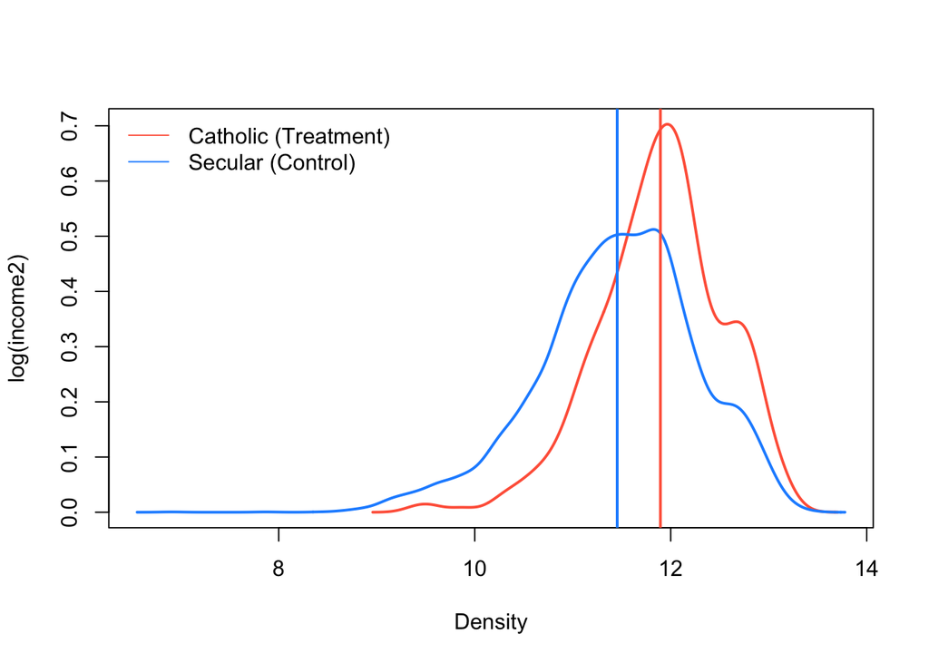

2. Do you think mother’s age is an important variable to control for? Why, or why not? Use “DAG” language in your answer. (**1 Point**)

```r
library(dagitty)

mathcathdag <- dagitty("dag {
                       MathScore [outcome]
                       CathSch [exposure]
                       Income -> MathScore
                       CathSch -> MathScore
                       Income -> CathSch
                       MotherAge -> Income
                       CathRel -> CathSch
                       MotherColl -> MotherAge
                       MotherColl -> Income
                       CathRel -> MotherAge
                       Income -> MotherAge
                       CathRel -> TwoParent
                       TwoParent -> Income
                       TwoParent -> MathScore
                       }")
plot(mathcathdag)
cat("Adjustment Set for DAG:\n")
print(adjustmentSets(mathcathdag, effect = "total"))
paths(mathcathdag)
```

**Output**

```
Adjustment Set for DAG:
{ Income, TwoParent }
{ CathRel, Income }
$paths
 [1] "CathSch -> MathScore"
 [2] "CathSch <- CathRel -> MotherAge -> Income -> MathScore"
 [3] "CathSch <- CathRel -> MotherAge -> Income <- TwoParent -> MathScore"
 [4] "CathSch <- CathRel -> MotherAge <- Income -> MathScore"
 [5] "CathSch <- CathRel -> MotherAge <- Income <- TwoParent -> MathScore"
 [6] "CathSch <- CathRel -> MotherAge <- MotherColl -> Income -> MathScore"
 [7] "CathSch <- CathRel -> MotherAge <- MotherColl -> Income <- TwoParent -> MathScore"
 [8] "CathSch <- CathRel -> TwoParent -> Income -> MathScore"
 [9] "CathSch <- CathRel -> TwoParent -> MathScore"
[10] "CathSch <- Income -> MathScore"
[11] "CathSch <- Income -> MotherAge <- CathRel -> TwoParent -> MathScore"
[12] "CathSch <- Income <- MotherAge <- CathRel -> TwoParent -> MathScore"
[13] "CathSch <- Income <- MotherColl -> MotherAge <- CathRel -> TwoParent -> MathScore"
[14] "CathSch <- Income <- TwoParent -> MathScore"

$open
 [1]  TRUE  TRUE FALSE FALSE FALSE FALSE FALSE  TRUE  TRUE  TRUE FALSE  TRUE
[13] FALSE  TRUE
```

**Plot**

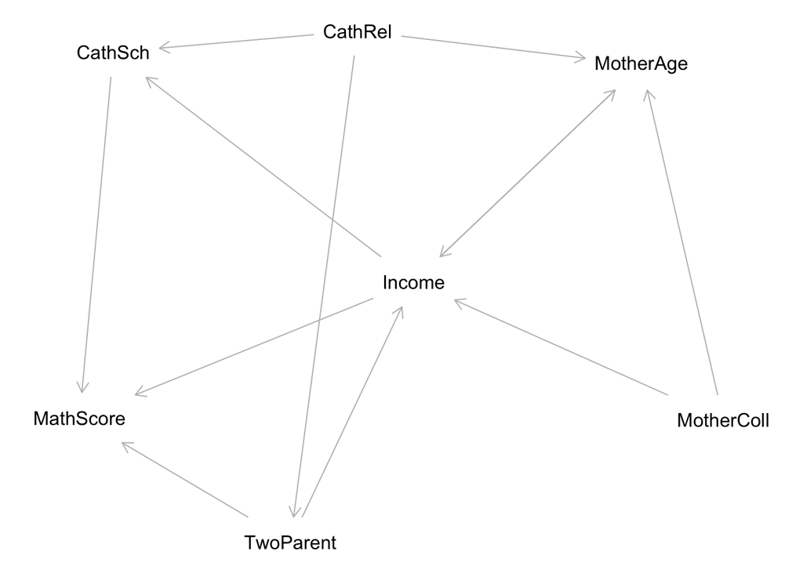

Considering the DAG above, it appears that mother’s age does not need to be controlled for as no open backdoors arise from this variable. In this DAG, I left mother’s age and income as causal to each other and even if income is causal to mother’s age, mother’s age is a collider, and if the opposite is true then income is a mediator between it and the treatment.

3. Regardless of your answer to the previous question, what are some other factors (that may or may not exist in the dataset) that might be important to control for? Again, use “DAG” language in your answer. (**2 Points**)

Income, however, was identified as a backdoor path that needs to be controlled for. Potentially being of the Catholic religion or being part of a two parent household need to be controlled for as they are both potential backdoors.

## Question 3

Begin working through the matching procedure.

1. Estimate a propensity score model using mother’s age, mother’s education, and family income as predictors.[^2] (**2 Points**)

```r
library(MatchIt)
reg_i2 <- glm(catholic ~ mom_age + mom_noCollege + income2,
              data = school,
              family = binomial(link = "logit"))

school$ps <- predict(reg_i2, type = "response")

school_m <- matchit(catholic ~ mom_age + mom_noCollege + income2,
                    data = school,
                    method = "nearest",
                    distance = "glm")
secular_D2 <- density(school$ps[school$catholic==0])
parochial_D2 <- density(school$ps[school$catholic==1])
plot(0, 0, type = "n",
     xlab = "Propensity Score",
     ylab = "Density",
     ylim = range(parochial_D2$y, secular_D2$y),
     xlim = range(parochial_D2$x, secular_D2$x))
lines(parochial_D2$x, parochial_D2$y, col = "tomato", lwd = 2)
lines(secular_D2$x, secular_D2$y, col = "dodgerblue", lwd = 2)
abline(v = mean(school$ps[school$catholic == 1]), col = "tomato", lwd = 2)
abline(v = mean(school$ps[school$catholic == 0]), col = "dodgerblue", lwd = 2)
legend("topright",
       legend = c("Catholic (Treatment)", "Secular (Control)"),
       col = c("tomato",
               "dodgerblue"),
       bty = "n",
       lty = 1)
options(scipen=999)
summary(reg_i2)
```

**Output**

```
Call:
glm(formula = catholic ~ mom_age + mom_noCollege + income2, family = binomial(link = "logit"),
    data = school)

Coefficients:
                   Estimate    Std. Error z value             Pr(>|z|)
(Intercept)   -3.2355665732  0.2252265194 -14.366 < 0.0000000000000002 ***
mom_age        0.0348927338  0.0056130927   6.216       0.000000000509 ***
mom_noCollege -0.7090833506  0.0793707189  -8.934 < 0.0000000000000002 ***
income2        0.0000028918  0.0000003033   9.534 < 0.0000000000000002 ***
---
Signif. codes:  0 '***' 0.001 '**' 0.01 '*' 0.05 '.' 0.1 ' ' 1

(Dispersion parameter for binomial family taken to be 1)

    Null deviance: 6558.3  on 7518  degrees of freedom
Residual deviance: 6201.0  on 7515  degrees of freedom
AIC: 6209

Number of Fisher Scoring iterations: 5
```

**Plot**

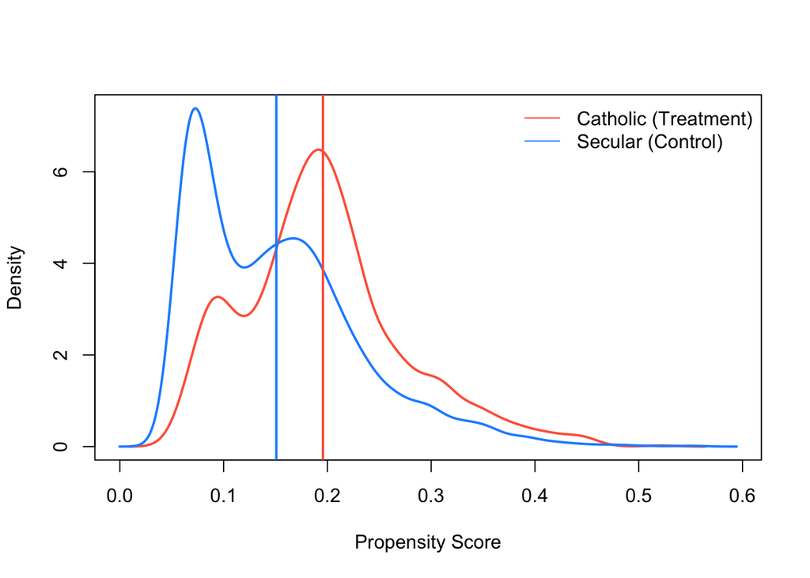

2. Interpret the signs of the model’s estimated coefficients. (**2 Points**)

Intercept: Constant, not meaningful. mom_age: Each additional year in mother’s age correlates to a $3.49\%$ increase in likelihood of a child attending catholic school. mom_noCollege: If a mother did not attend college a child is $70.9\%$ less likely to attend catholic school. income2: Each additional $\$1000$ in income makes a child $0.2\%$ more likely to attend catholic school.

3. Using this model, , create inverse probability weights as a new variable called `w` in `school`. (**2 Point**)

```r
school$w <- (school$catholic / school$ps) + ((1 - school$catholic) / (1 - school$ps))
```

4. Using these weights, re-create the income distributions from before. Comment on any similarities/differences.[^3] (**2 Points**)

```r
reg_i2_w <- glm(catholic ~ mom_age + mom_noCollege + income2,
              data = school,
              family = binomial(link = "logit"),
              weights = school$w)

school$ps <- predict(reg_i2_w, type = "response")

school_m_w <- matchit(catholic ~ mom_age + mom_noCollege + income2,
                    data = school,
                    method = "nearest",
                    distance = "glm")
secular_D2 <- density(school$ps[school$catholic==0], weights = school$w[school$catholic==0])
parochial_D2 <- density(school$ps[school$catholic==1], weights = school$w[school$catholic==1])
plot(0, 0, type = "n",
     xlab = "Propensity Score",
     ylab = "Density",
     ylim = range(parochial_D2$y, secular_D2$y),
     xlim = range(parochial_D2$x, secular_D2$x))
lines(parochial_D2$x, parochial_D2$y, col = "tomato", lwd = 2)
lines(secular_D2$x, secular_D2$y, col = "dodgerblue", lwd = 2)
# abline(v = mean(school$ps[school$catholic == 1]), col = "tomato", lwd = 2)
# abline(v = mean(school$ps[school$catholic == 0]), col = "dodgerblue", lwd = 2)
legend("topright",
       legend = c("Catholic (Treatment)", "Secular (Control)"),
       col = c("tomato",
               "dodgerblue"),
       bty = "n",
       lty = 1,
       cex = 0.75)
options(scipen=999)
summary(reg_i2_w)
```

**Output**

```
Call:
glm(formula = catholic ~ mom_age + mom_noCollege + income2, family = binomial(link = "logit"),
    data = school, weights = school$w)

Coefficients:
                   Estimate    Std. Error z value       Pr(>|z|)
(Intercept)   -0.7201703113  0.1160474209  -6.206 0.000000000544 ***
mom_age        0.0147786038  0.0029478404   5.013 0.000000534859 ***
mom_noCollege -0.0304299010  0.0359739413  -0.846          0.398
income2        0.0000008898  0.0000001808   4.922 0.000000857421 ***
---
Signif. codes:  0 '***' 0.001 '**' 0.01 '*' 0.05 '.' 0.1 ' ' 1

(Dispersion parameter for binomial family taken to be 1)

    Null deviance: 20480  on 7518  degrees of freedom
Residual deviance: 20409  on 7515  degrees of freedom
AIC: 19027

Number of Fisher Scoring iterations: 5
```

**Plot**

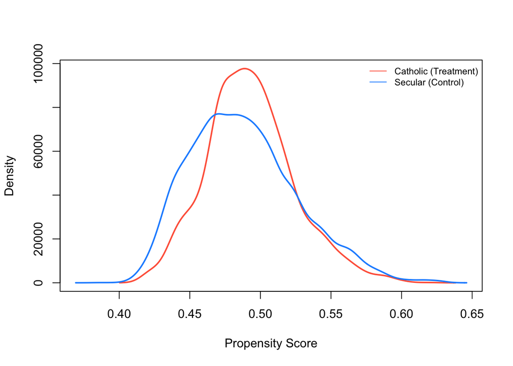

mom_age: The new model predicts that a $1$ year increase in mother’s age will increase the likelihood that a child will attend catholic school by $1.48\%$. mom_noCollege: If a mother didn’t attend college the likelihood of a child attending catholic school decreases by $3.04\%$ which is a significant change from the unweighted model and it is no longer considered statistically significant. income2: The model now predicts that each $\$1000$ increase in income will increase the likelihood of a child attending catholic school by $0.08\%$.

## Question 4

In the following parts, estimate the two models below linking catholic school enrollment and math scores. The functional forms are:

$$\text{Math}_i = \alpha + \delta \text{Catholic}_i + \epsilon_i$$

$$\begin{aligned}\text{Math}_i = \alpha &+ \delta \text{Catholic}_i \\ &+ \beta_0\text{Mother's Age}_i \\&+ \beta_1 \text{Mother's Education}_i \\&+ \beta_2log(\text{Family Income}_i) + \epsilon_i\end{aligned}$$

1. First estimate the models’ parameters using OLS and store them as `r_ols1` and `r_ols2`. You do not need to display the results quite yet. (**2 Points**)

```r
r_ols1 <- lm(math_score ~ catholic, data = school)
r_ols2 <- lm(math_score ~ catholic + mom_age + mom_noCollege + log(income2), data = school)
```

2. Use the `MatchIt` package in R to create a matched sample (match based on mahalanobis distance). Then, estimate the parameters with OLS using the matched sample. Store these as `r_match1` and `r_match2`. Again, hold off on displaying these coefficients. (**3 Points**)

```r
school_m2 <- school
m.out <- matchit(catholic ~ mom_age + mom_noCollege + income2, data = school_m2, method = "nearest", distance = "mahalanobis")
school_m2 <- match.data(m.out, drop.unmatched = TRUE)
r_match1 <- lm(math_score ~ catholic, data = school_m2)
r_match2 <- lm(math_score ~ catholic + mom_age + mom_noCollege + log(income2), data = school_m2)
```

3. Estimate the parameters with OLS using the inverse probability weights you generated before. Store these estimations as `r_ipw1` and `r_ipw2`. (**3 Points**)

```r
r_ipw1 <- lm(math_score ~ catholic, data = school_m2, weights = w)
r_ipw2 <- lm(math_score ~ catholic + mom_age + mom_noCollege + log(income2), data = school_m2, weights = w)
```

4. Display the coefficients of the above six models in a table generated by `modelsummary`. (**2 Points**)

```r
regz <- list("OLS" = r_ols1,
             "PSM" = r_match1,
             "IPW" = r_ipw1,
             "OLS Controls" = r_ols2,
             "PSM Controls" = r_match2,
             "IPW Controls" =r_ipw2)
modelsummary(regz, stars = TRUE)
```

**Output**

|  | OLS | PSM | &nbsp;IPW | OLS Controls | PSM Controls | &nbsp;IPW Controls |
| --- | --- | --- | --- | --- | --- | --- |
| (Intercept) | 51.653*** | 54.241*** | 54.569*** | 12.730*** | 18.655*** | 26.093*** |
|  | (0.119) | (0.256) | (0.423) | (1.716) | (3.505) | (3.403) |
| catholic | 1.262*** | −1.326*** | −2.578*** | −1.039*** | −1.321*** | −1.372** |
|  | (0.300) | (0.363) | (0.465) | (0.285) | (0.345) | (0.455) |
| mom_age |  |  |  | 0.109*** | 0.134*** | 0.151*** |
|  |  |  |  | (0.017) | (0.035) | (0.033) |
| mom_noCollege |  |  |  | −3.236*** | −3.915*** | −3.035*** |
|  |  |  |  | (0.229) | (0.433) | (0.374) |
| log(income2) |  |  |  | 3.160*** | 2.614*** | 1.927*** |
|  |  |  |  | (0.144) | (0.284) | (0.275) |
| Num.Obs. | 7519 | 2374 | 2374 | 7519 | 2374 | 2374 |
| R2 | 0.002 | 0.006 | 0.013 | 0.147 | 0.103 | 0.090 |
| R2 Adj. | 0.002 | 0.005 | 0.012 | 0.146 | 0.101 | 0.088 |
| AIC | 55186.8 | 17083.8 | 17708.2 | 54015.8 | 16845.1 | 17521.3 |
| BIC | 55207.6 | 17101.1 | 17725.5 | 54057.3 | 16879.7 | 17555.9 |
| Log.Lik. | −27590.409 | −8538.894 | −8851.109 | −27001.888 | −8416.537 | −8754.644 |
| F | 17.677 | 13.370 | 30.746 | 323.497 | 68.008 | 58.468 |
| RMSE | 9.49 | 8.83 | 8.85 | 8.78 | 8.38 | 8.41 |

+ p < 0.1, * p < 0.05, ** p < 0.01, *** p < 0.001

## Question 5

Discuss the results of the estimations. Make sure to discuss difference between methods (OLS, PSM, and IPW) as well as models (controls, no controls). (**4 Points**)

In naïve OLS, the model predicts that math scores will increase by $1.262$ units if the student is enrolled in catholic school, however with matching and weighting the model predicts a drop in math scores by $1.326$ and $2.578$ respectively. When controlled for mother’s age, mother’s education, and family income, catholic school as a detrimental effect for all three models (OLS, PSM, and IPW). Family income appears to be the most significant contributing factors to math scores. I would suggest that mother’s education add some collinearity to the model, as I would consider that causal to income.

## Question 6

Write up your takeaways from this analysis. Do you believe catholic school is better than public school in terms of math education? Which model do you believe the most? Is matching appropriate in this setting? In other words, are the assumptions required to interpret these results as causal satisfied or have they been violated? (**4 Points**)

It would appear that catholic school is not better than public school in terms of math education. I think there is some collinearity by adding mother’s education to the model, however. Mother’s education is likely causal to family income, so I would remove that from the model. Otherwise, I believe the matched and weighted models are appropriate for estimation as this addresses the fact that there is a great deal more dispersion in math scores among public school students vs. catholic school students. Matching and weighting get us closer to “ceteris paribus” and removing the noise that comes from the dispersion among students in public schools.

## Footnotes

[^1]: [Hint](https://alexcardazzi.github.io/econ400/module04/module04-01_notes.html#:~:text=Let%E2%80%99s%20plot%20both%20distributions.)
[^2]: Remember: propensity score models are often estimated using logistic regression.
[^3]: Hint: `density()` contains an option for weights.